# Rock vs. Pop Music: How are they the same? How do they differ?

Marsya Chairuna (mc4813)

[figure not shown]

Rock and Pop fans have stirred up debates across internet forums and websites. Based on several internet forums and articles, such as in [Quora](https://www.quora.com/Why-do-some-people-hate-pop-music) and [Guardian](https://www.theguardian.com/music/2013/oct/11/david-byrne-internet-content-world)), Rock fans perceive pop music as overly simplistic, unmeaningful in both chords and lyrics. However, some articles from modern music journalist, such as [this article](https://spinditty.com/genres/rock-music-comeback), said that rock has become too serious to be relevant.

> Setting aside the chords, how do they actually differ in terms of lyrics and sentiments? Are they really distinguishable?

In summary, the questions we are interested in answering are:

- *Words and Sentences:* What are the most frequent word(s) used in lyrics for each rock and pop genre? How the length of characters differs?
- *Sentiment:* Do we have a different type of sentiment/emotion between rock and pop?
- *Predictability:* Can we predict the whether a song’s genre is rock or pop?

## Topic 1: Words and Sentences

### What are the most frequent words used in lyrics for each rock and pop genre?

For the first topic, we want to know what are the most frequent words in lyrics of rock and pop music. First, we want to inspect the word cloud for each rock and pop genre using *wordcloud* package. The more a specific word appears in a source of textual data, that is song lyrics, the bigger and bolder it appears in the word cloud.

At glance, we can observe that both genres have the word *“love”*, *“time”*, and *“youre”* as ones of their most common words in lyrics.

#### Word Cloud

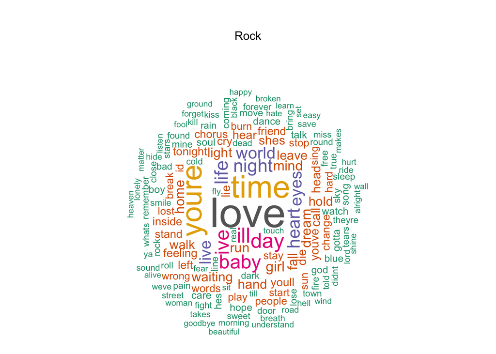

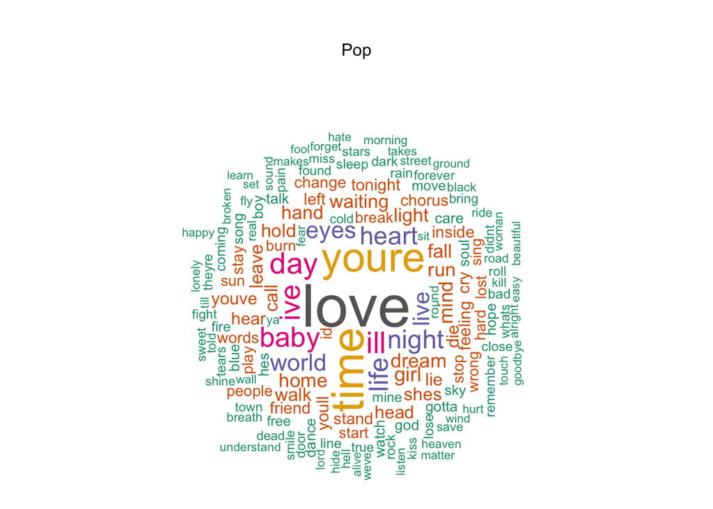

We will take a closer look of each genre’s most frequent words by calculating the proportional or relative frequency of each word in a genre. The plot below illustrates the top 10 words that have the highest relative frequency in all song titles for each genre.

Rock and pop genres have several common words in their top 10 words, such as “love”, “time”, “day”, “night”, “life”, “baby”, and “heart”. Therefore, both genres have similar word-by-word choices in their lyrics.

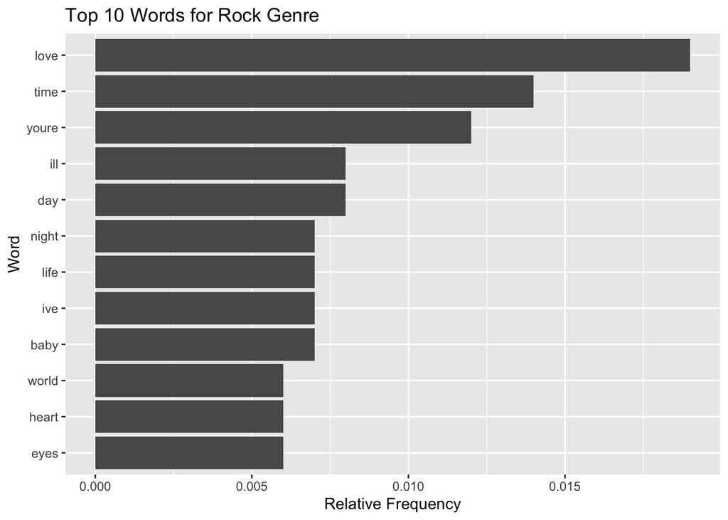

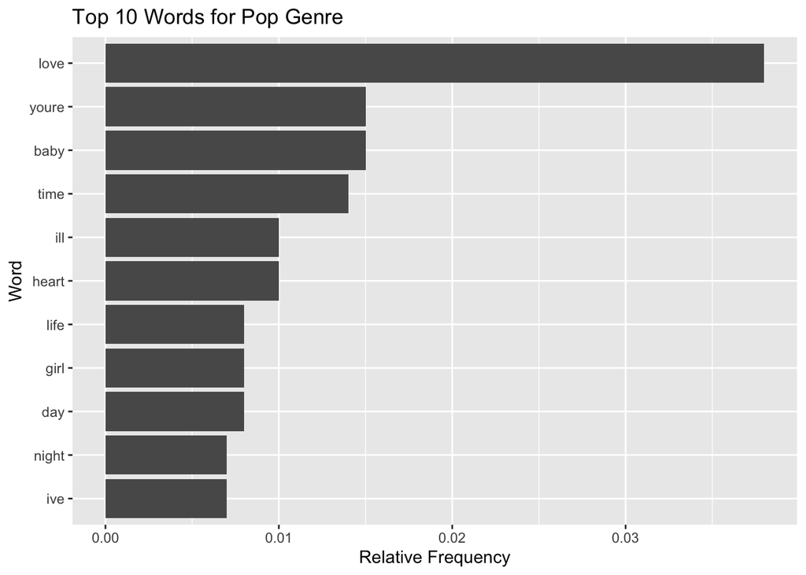

### How the length of sentences (in words) differs between Rock and Pop genre?

We will now observe which music genre uses more lyrics in terms of average number of words per song.

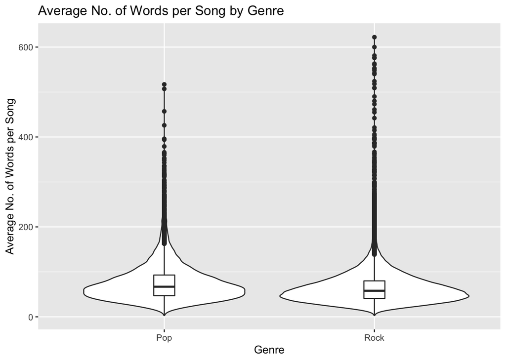

Both genres have similar values in terms of median, quartiles, and ranges of average number of words per songs, which indicate their distributions of average number of words per song are similar. However, rock songs have more extreme values compared to pop songs, as demonstrated by the dots in 500-600 average no. of words region.

## Topic 2: Sentiments

### Do we have a different type of sentiment between rock and pop?

#### NCR Sentiment

Next, we will conduct sentimental analysis on song lyrics. By 10 different sentiments of NRC lexicon, we can obtain a proportion of each sentiment per genre. The distributions of sentiments between the two groups have a distinctive pattern.

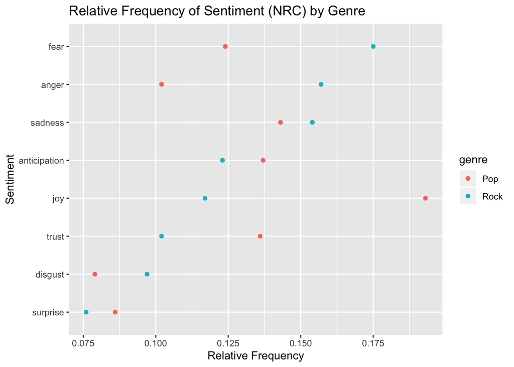

## Topic 3: Predictability

### Can we predict the whether a song’s genre is rock or pop?

Next, we want to see if a song’s genre can be predicted using predictors that we have used in previous analysis, which are number of characters and prominent sentiment. Because the prediction outcome is between “rock” and “pop” genre, we will use logistic regression using caTools library. We will first load the library and create an appropriate data frame as an input for logistic regression.

- We will use a dummy variable to represent “Rock” and “Pop” genre, with “Rock” genre written as “1” and “Pop” genre written as “0”.
- Note: To minimize computing duration, we will use a sample of 10,000 rows from the overall dataset.

#### Creating data frame as an input for logistic regression

```
## # A tibble: 6 x 5
## # Groups:   id [6]
##      id genre_lr n_char word      sentiment
##   <int>    <dbl>  <int> <chr>     <chr>
## 1 32765        0   1373 ready     anticipation
## 2 61001        0   1615 beautiful joy
## 3 68555        0   1226 ready     anticipation
## 4 68561        0   1249 ready     anticipation
## 5 88335        1   1108 goo       disgust
## 6 88424        1   1108 goo       disgust
```

We then continued to split the data into train and test dataset, with a split ratio of 70% and 30%. Therefore, train dataset will have a number of rows of 7,000 and test dataset will have 3,000.

#### Sampling data and splitting data into test and train

```r
library(caTools)
set.seed(123)
data_lr <- data_lr[sample(nrow(data_lr), 10000), ]
split = sample.split(data_lr$genre_lr,SplitRatio = 0.7)
train = data_lr[split,]
test = data_lr[!split,]
```

We then checked the result of our split to check if the number of rows is correct.

#### Explore

```
## [1] 7000
```

```
## [1] 3000
```

```
## [1] 0.7728571
```

```
## [1] 0.773
```

#### Constructing the model

```r
model3 = glm(genre_lr~n_char+sentiment,
             data=train,
             family='binomial')

summary(model3)
```

```
##
## Call:
## glm(formula = genre_lr ~ n_char + sentiment, family = "binomial",
##     data = train)
##
## Deviance Residuals:
##     Min       1Q   Median       3Q      Max
## -2.0915   0.5470   0.6313   0.7227   1.7443
##
## Coefficients:
##                         Estimate Std. Error z value Pr(>|z|)
## (Intercept)            1.9052091  0.0909323  20.952   <2e-16 ***
## n_char                -0.0011653  0.0001301  -8.956   <2e-16 ***
## sentimentanticipation -0.0801002  0.0968779  -0.827    0.408
## sentimentdisgust       0.0822027  0.1775843   0.463    0.643
## sentimentfear          0.2003492  0.1540504   1.301    0.193
## sentimentjoy          -0.7400204  0.0884360  -8.368   <2e-16 ***
## sentimentnegative     -0.1257603  0.1168220  -1.077    0.282
## sentimentpositive     -0.0551125  0.1110991  -0.496    0.620
## sentimentsadness       0.1962780  0.3005735   0.653    0.514
## sentimentsurprise      0.2478927  0.2662712   0.931    0.352
## sentimenttrust         0.0754248  0.2770773   0.272    0.785
## ---
## Signif. codes:  0 '***' 0.001 '**' 0.01 '*' 0.05 '.' 0.1 ' ' 1
##
## (Dispersion parameter for binomial family taken to be 1)
##
##     Null deviance: 7501.2  on 6999  degrees of freedom
## Residual deviance: 7293.1  on 6989  degrees of freedom
## AIC: 7315.1
##
## Number of Fisher Scoring iterations: 4
```

#### Predict on test

```r
sum(test$genre_lr==0)/nrow(test)
```

```
## [1] 0.227
```

#### Accuracy, Specificity, Sensitivity

```
##         predictions
## genre_lr    0    1
##        0   11  670
##        1    4 2315
```

*Accuracy*

```
## [1] 0.7753333
```

*Specificity*

```
## [1] 0.01615272
```

*Sensitivity*

```
## [1] 0.9982751
```

The poor predictability of the model can be improved by the following action steps: - Adding more data points for pop songs, because in the source dataset, rock songs accounted for 51.6% of total songs, while pop songs only accounted for 14.9%. - Refining the current predictors or adding more predictor variables, such as sentiment scores by afinn lexicon, vocabulary size, etc.

# Summary

- Both genres have similar word-by-word choices such as “love”, “time”, “day”, “night”, “life”, “baby”, and “heart”. Their average number of words per song are also similar, as demonstrated by their distributions. However, rock songs have more songs with significantly large number of words. (500-600 words per song) compared to pop songs.
- The lyrics of rock songs tend to be more of negative sentiments such as “fear”, “anger”, and “sadness”, as opposed to those of pop songs are slightly more likely to be positive than negative.
- Our model is yet to be improved in accuracy, because most of the observations are predicted as rock songs. The model can be improved by adding more data points for pop songs and refining/adding predictors.